Eat 4 Life Marketing · AI Marketing Made Easy

# AI Search Visibility Report — Golden Plumbing

Louisville, KY · Plumbing · October 2026 · baseline audit

2of 28 AI answers  
name Golden Plumbing

We asked **ChatGPT, Gemini, and Claude** the 7 questions your customers actually type when they're ready to buy — fresh sessions, no history, just like a real person. AI already names Golden Plumbing in 2 answers — the plan below grows that number. *Perplexity could not be captured this run, so 7 of the 28 answers counted above are untested rather than misses — it re-tests next cycle.*

## Platform by platform

ChatGPT

1/7

Recommends Golden Plumbing on 1 of 7 questions.

Gemini

1/7

Recommends Golden Plumbing on 1 of 7 questions.

Perplexity

—

Could not be tested this run — it limits automated logged-out questions. It re-tests next cycle.

Claude

0/7

Answered 7 of 7 questions and never mentioned Golden Plumbing.

## Question by question

| What your customers ask AI | ChatGPT | Gemini | Perplexity | Claude |
| --- | --- | --- | --- | --- |
| emergency plumber near Louisville, KY | — | — | ✗ | — |
| most reliable plumber in Louisville, KY | — | — | ✗ | — |
| plumber that answers the phone Louisville, KY | ✓ | — | ✗ | — |
| best-reviewed plumber near me Louisville, KY | — | — | ✗ | — |
| plumber Louisville, KY free estimate | — | ✓ | ✗ | — |
| who should I call for a burst pipe in Louisville, KY | — | — | ✗ | — |
| plumber open now Louisville, KY | — | — | ✗ | — |

✓ Golden Plumbing named · — answered, not named · ✗ not tested this run

## Who AI recommends instead

Across all answers this month, these businesses were named — each mention is a customer conversation happening without you:

- **ASI Plumbing** — named 9×
- **Dauenhauer Plumbing** — named 5×
- **1-Tom-Plumber** — named 5×
- **Jarboe's Heating, Cooling & Plumbing** — named 5×
- **Daniel Brown Plumbing** — named 5×
- **Roto-Rooter** — named 4×
- **Your Second Opinion Plumbing** — named 4×
- **Benjamin Franklin Plumbing** — named 4×

## The receipts

Exactly what the AI said, captured the moment we asked:

[figure not shown]

ChatGPT — “plumber that answers the phone Louisville, KY” — Golden Plumbing is named.

[figure not shown]

Gemini — “plumber Louisville, KY free estimate” — Golden Plumbing is named.

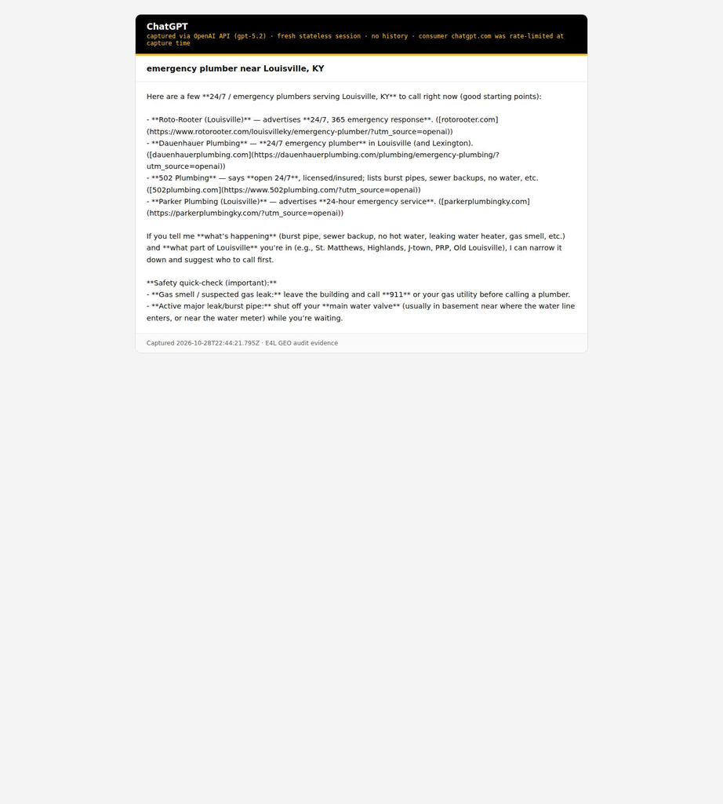

ChatGPT — “emergency plumber near Louisville, KY” — others are recommended; Golden Plumbing is absent.

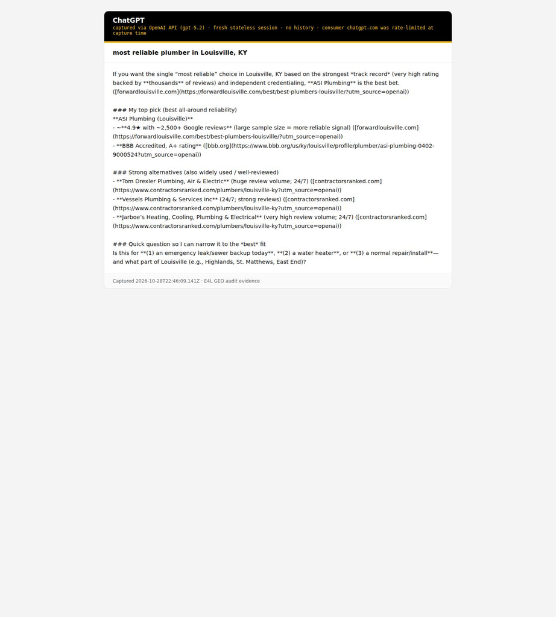

ChatGPT — “most reliable plumber in Louisville, KY” — others are recommended; Golden Plumbing is absent.

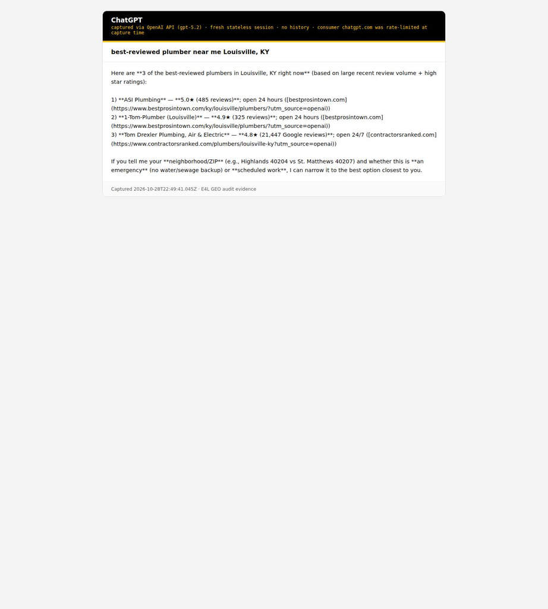

ChatGPT — “best-reviewed plumber near me Louisville, KY” — others are recommended; Golden Plumbing is absent.

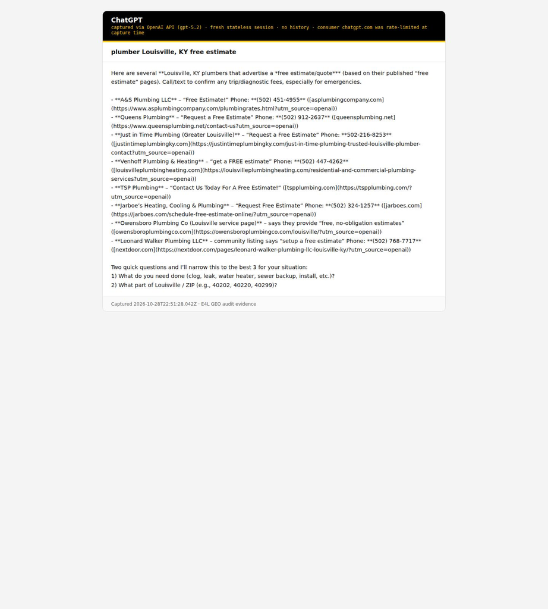

ChatGPT — “plumber Louisville, KY free estimate” — others are recommended; Golden Plumbing is absent.

## Dashboard line

**AI VISIBILITY — October 2026. Baseline: named in 2/28 AI answers. This month: named in 2/28. Screenshots attached. Next: re-test Perplexity once its limit resets.**